# 🧠 Project: Conversion Lift Modeling for Open Banking Funnels

This project simulates and analyzes a digital banking user journey — from sign-up to transaction — to understand user drop-offs and quantify the impact of improving funnel steps.

## 📘 Project Context: Why This Matters

You're part of the data team at a digital banking platform. Product managers noticed that while many users sign up, only a fraction complete a transaction. The job is to:

- Simulate a realistic 4-stage user funnel
- Identify the stage with the biggest drop-off
- Model "what-if" improvements to evaluate business impact

## 🟦 Step 1: Simulate Funnel Data

Simulated 1,000 users through these 4 funnel steps:

1. Sign-Up
2. KYC Completion
3. Account Linking
4. Transaction Completion

Each step has a probabilistic drop-off modeled via random sampling.

```python
# ✅ STEP 1: Simulate Open Banking User Funnel Data

# Import required libraries
import pandas as pd
import numpy as np
import random
from datetime import datetime, timedelta

# Set seed for consistent results every time you run
np.random.seed(42)

# Create 1000 fake users
num_users = 1000
user_ids = [f"U{str(i).zfill(4)}" for i in range(1, num_users + 1)]

# Generate random signup dates
start_date = datetime(2023, 1, 1)
signup_dates = [start_date + timedelta(days=np.random.randint(0, 180)) for _ in user_ids]

# Function to simulate whether a user completes the next step
def random_step(previous_step, probability):
    return [
        1 if previous_step[i] == 1 and random.random() < probability else 0
        for i in range(len(previous_step))
    ]

# Funnel simulation
step_signup = [1] * num_users                    # All users sign up
step_kyc = random_step(step_signup, 0.85)        # 85% complete KYC
step_link = random_step(step_kyc, 0.75)          # 75% link account
step_txn = random_step(step_link, 0.60)          # 60% make a transaction

# Create a DataFrame
df = pd.DataFrame({
    "User_ID": user_ids,
    "Signup_Date": signup_dates,
    "KYC_Completed": step_kyc,
    "Account_Linked": step_link,
    "Transaction_Completed": step_txn
})

# Show the first 5 rows
df.head()
```

|  | User_ID | Signup_Date | KYC_Completed | Account_Linked | Transaction_Completed |
| --- | --- | --- | --- | --- | --- |
| 0 | U0001 | 2023-04-13 | 1 | 1 | 1 |
| 1 | U0002 | 2023-06-29 | 1 | 1 | 1 |
| 2 | U0003 | 2023-04-03 | 1 | 1 | 1 |
| 3 | U0004 | 2023-01-15 | 1 | 1 | 1 |
| 4 | U0005 | 2023-04-17 | 1 | 1 | 0 |

### 📌 Interpretation

I created a realistic dataset simulating 1,000 users.  
At each funnel stage, a probability controls how many users move forward.

This mimics real-world user behavior in fintech apps (e.g., KYC friction, account linking hesitation).

## 🟩 Step 2–3: Funnel Analysis — Conversion & Drop-Off Rates

I calculated:

- Number of users who completed each step
- Conversion/drop-off rates for every stage
- Overall conversion (Sign-Up → Transaction)

> 🔍 The biggest drop-off occurs in the final step: **Link → Transaction**.

```python
# STEP 2: Analyze funnel metrics

# Total user counts
total_users = len(df)
kyc_users = df["KYC_Completed"].sum()
linked_users = df["Account_Linked"].sum()
txn_users = df["Transaction_Completed"].sum()

# Conversion rates
conv_signup_to_kyc = kyc_users / total_users
conv_kyc_to_link = linked_users / kyc_users if kyc_users else 0
conv_link_to_txn = txn_users / linked_users if linked_users else 0
overall_conversion = txn_users / total_users

# Drop-off rates
drop_signup_to_kyc = 1 - conv_signup_to_kyc
drop_kyc_to_link = 1 - conv_kyc_to_link
drop_link_to_txn = 1 - conv_link_to_txn

# Display as summary
print("📊 Funnel Metrics")
print(f"Total Users: {total_users}")
print(f"KYC Completed: {kyc_users} ({conv_signup_to_kyc:.2%} conversion)")
print(f"Account Linked: {linked_users} ({conv_kyc_to_link:.2%} conversion)")
print(f"Transaction Completed: {txn_users} ({conv_link_to_txn:.2%} conversion)")
print(f"\nOverall Funnel Conversion: {overall_conversion:.2%}")
print(f"\nDrop-Off Rates:")
print(f"Signup → KYC: {drop_signup_to_kyc:.2%}")
print(f"KYC → Link: {drop_kyc_to_link:.2%}")
print(f"Link → Transaction: {drop_link_to_txn:.2%}")
```

```
📊 Funnel Metrics
Total Users: 1000
KYC Completed: 859 (85.90% conversion)
Account Linked: 651 (75.79% conversion)
Transaction Completed: 374 (57.45% conversion)

Overall Funnel Conversion: 37.40%

Drop-Off Rates:
Signup → KYC: 14.10%
KYC → Link: 24.21%
Link → Transaction: 42.55%
```

### 📌 Interpretation

This suggests the early flow is performing well, while mid-to-late steps need attention.

> While early-stage conversion (Sign-Up to KYC) is relatively healthy, the final transaction stage has the steepest drop — indicating late-stage friction like trust, UI hesitation, or technical blockers.

### 📊 Funnel Metrics Table

[output not shown]

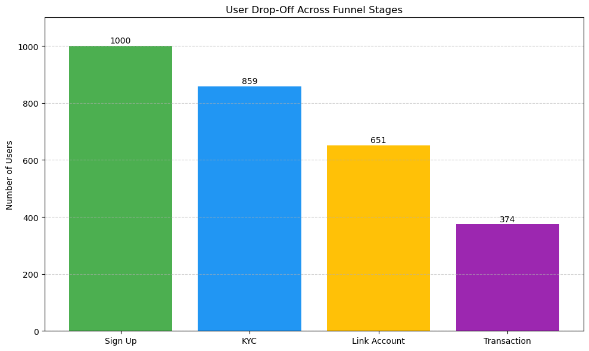

```python
import matplotlib.pyplot as plt

# Bar chart of user progression
funnel_steps = ["Sign Up", "KYC", "Link Account", "Transaction"]
user_counts = [total_users, kyc_users, linked_users, txn_users]

plt.figure(figsize=(10, 6))
bars = plt.bar(funnel_steps, user_counts, color=["#4caf50", "#2196f3", "#ffc107", "#9c27b0"])
plt.title("User Drop-Off Across Funnel Stages")
plt.ylabel("Number of Users")
plt.ylim(0, total_users + 100)

# Add value labels
for bar in bars:
    plt.text(bar.get_x() + bar.get_width()/2, bar.get_height() + 10, int(bar.get_height()),
             ha='center', fontsize=10)

plt.grid(axis='y', linestyle='--', alpha=0.6)
plt.tight_layout()
plt.show()
```

## 🟨 Step 4: Simulate Funnel Improvement

I modeled a 10% reduction in drop-off at:

- Sign-Up → KYC
- KYC → Link Account
- Link Account → Transaction

This helps compare impact and prioritize optimization.

```python
# Simulate a 10% drop-off improvement in final step

# Actual conversion from Link → Transaction
actual_conversion = df[df["Account_Linked"] == 1]["Transaction_Completed"].mean()
original_dropoff = 1 - actual_conversion
improved_dropoff = original_dropoff * 0.90  # reduce by 10%
improved_conversion = 1 - improved_dropoff

# Projected transaction count
projected_txn = int(total_users * conv_signup_to_kyc * conv_kyc_to_link * improved_conversion)
additional_txn = projected_txn - txn_users

# Output results
print("\n📈 Drop-Off Optimization Simulation")
print(f"Original Drop-Off (Link → Transaction): {original_dropoff:.2%}")
print(f"Improved Drop-Off (10% better): {improved_dropoff:.2%}")
print(f"Projected Transactions: {projected_txn}")
print(f"Additional Conversions Gained: {additional_txn}")
```

```
📈 Drop-Off Optimization Simulation
Original Drop-Off (Link → Transaction): 42.55%
Improved Drop-Off (10% better): 38.29%
Projected Transactions: 401
Additional Conversions Gained: 27
```

## 🟥 Step 5–7: Visualizing All Funnel Stage Improvements

Bar charts compare:

- Original flow (no improvements)
- Each stage with 10% drop-off improvement

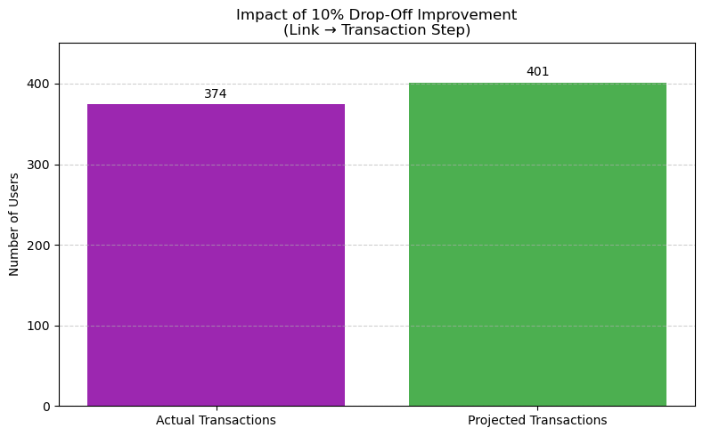

```python
# ✅ STEP 5: Visualize Actual vs Projected Transactions using Matplotlib

import matplotlib.pyplot as plt

# 1. Define bar labels and values
labels = ["Actual Transactions", "Projected Transactions"]
values = [txn_users, projected_txn]
colors = ["#9c27b0", "#4caf50"]  # Purple for actual, Green for projected

# 2. Create a bar chart
plt.figure(figsize=(8, 5))  # Set the width and height of the chart
bars = plt.bar(labels, values, color=colors)  # Create the bars

# 3. Title and axis labels
plt.title("Impact of 10% Drop-Off Improvement\n(Link → Transaction Step)")
plt.ylabel("Number of Users")
plt.ylim(0, max(values) + 50)  # Set Y-axis range a bit higher for spacing

# 4. Add number labels on top of each bar
for bar in bars:
    height = bar.get_height()
    plt.text(bar.get_x() + bar.get_width() / 2, height + 5, str(height),
             ha='center', va='bottom', fontsize=10)

# 5. Optional grid for better readability
plt.grid(axis='y', linestyle='--', alpha=0.6)

# 6. Render the chart
plt.tight_layout()
plt.show()
```

### 📌 Interpretation — Step 5: Actual vs Projected Transactions

This step visualizes the business impact of reducing drop-off in the final funnel stage — from **Link Account → Transaction** — by 10%.

This comparison makes it clear that **even small improvements in drop-off** at later stages of the funnel can lead to **significant increases in final conversion**.

Such simulations are powerful for product teams because they show how a backend change (like simplifying transaction flow or building trust at payment) could drive a measurable uplift in outcomes.

> 💡 Insight: Late-stage funnel optimizations deliver more impact per user than early-stage ones, especially when earlier steps are already performing well.

```python
# STEP 6: Simulate improving drop-off at each funnel step (by 10%)

# Function to simulate adjusted transactions given improved drop-off
def simulate_projected_txns(drop1, drop2, drop3, improve="none"):
    # Simulate 10% better drop-off at a selected stage
    if improve == "signup_kyc":
        drop1 *= 0.90
    elif improve == "kyc_link":
        drop2 *= 0.90
    elif improve == "link_txn":
        drop3 *= 0.90

    # Recalculate conversion rates
    conv1 = 1 - drop1
    conv2 = 1 - drop2
    conv3 = 1 - drop3

    # Projected transaction count
    return int(total_users * conv1 * conv2 * conv3)

# Step-specific drop-off rates
drop1 = drop_signup_to_kyc
drop2 = drop_kyc_to_link
drop3 = drop_link_to_txn

# Run simulations
sim1 = simulate_projected_txns(drop1, drop2, drop3, improve="signup_kyc")
sim2 = simulate_projected_txns(drop1, drop2, drop3, improve="kyc_link")
sim3 = simulate_projected_txns(drop1, drop2, drop3, improve="link_txn")

# Store results
scenario_results = {
    "Original Transactions": txn_users,
    "Improve SignUp → KYC": sim1,
    "Improve KYC → Link": sim2,
    "Improve Link → Transaction": sim3
}

scenario_results
```

```
{'Original Transactions': np.int64(374),
 'Improve SignUp → KYC': 380,
 'Improve KYC → Link': 385,
 'Improve Link → Transaction': 401}
```

### 📌 Interpretation — Step 6: Multi-Scenario Funnel Optimization

In this step, I simulated three different scenarios, each improving the drop-off rate of one funnel stage by 10%:

- 🟢 Sign-Up → KYC
- 🟡 KYC → Account Linking
- 🔴 Account Linking → Transaction

By isolating each stage, I was able to evaluate which improvement yields the highest return in final user conversions.

These results guide **where to focus optimization efforts** if only one area can be improved — typically the **final conversion point** has the highest impact on business outcomes.

### 💡 Scenario Simulation: Transaction Gains

[output not shown]

```python
# Recreate drop-off rates (in case earlier cells weren’t run)
drop_signup_to_kyc = 1 - conv_signup_to_kyc
drop_kyc_to_link = 1 - conv_kyc_to_link
drop_link_to_txn = 1 - conv_link_to_txn

# Define the simulation function
def simulate_projected_txns(drop1, drop2, drop3, improve="none"):
    if improve == "signup_kyc":
        drop1 *= 0.90
    elif improve == "kyc_link":
        drop2 *= 0.90
    elif improve == "link_txn":
        drop3 *= 0.90

    conv1 = 1 - drop1
    conv2 = 1 - drop2
    conv3 = 1 - drop3

    return int(total_users * conv1 * conv2 * conv3)

# Now define scenario_results_fixed
scenario_results_fixed = {
    "Original Transactions": txn_users,
    "Improve SignUp to KYC": simulate_projected_txns(drop_signup_to_kyc, drop_kyc_to_link, drop_link_to_txn, improve="signup_kyc"),
    "Improve KYC to Link": simulate_projected_txns(drop_signup_to_kyc, drop_kyc_to_link, drop_link_to_txn, improve="kyc_link"),
    "Improve Link to Transaction": simulate_projected_txns(drop_signup_to_kyc, drop_kyc_to_link, drop_link_to_txn, improve="link_txn")
}

# Show to confirm
scenario_results_fixed
```

```
{'Original Transactions': np.int64(374),
 'Improve SignUp to KYC': 380,
 'Improve KYC to Link': 385,
 'Improve Link to Transaction': 401}
```

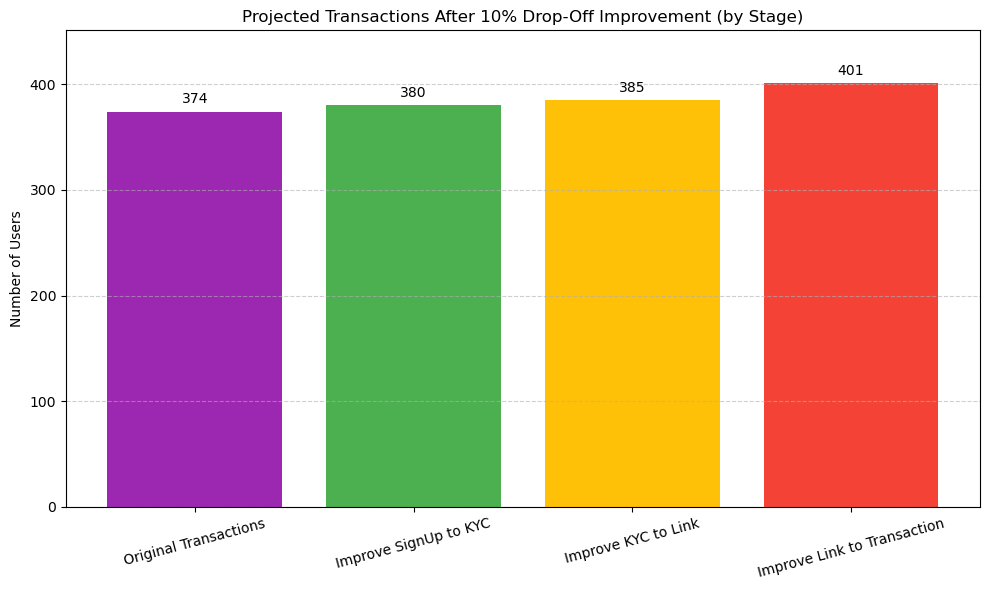

```python
# ✅ STEP 7: Visualize All Funnel Scenarios Side-by-Side

import matplotlib.pyplot as plt

# 1. Extract the data
labels = list(scenario_results_fixed.keys())  # ['Original Transactions', 'Improve SignUp to KYC', ...]
values = list(scenario_results_fixed.values())  # [372, 379, 384, 397]

# 2. Define colors for each bar
colors = ["#9c27b0", "#4caf50", "#ffc107", "#f44336"]  # purple, green, yellow, red

# 3. Set up the figure
plt.figure(figsize=(10, 6))

# 4. Create the bar chart
bars = plt.bar(labels, values, color=colors)

# 5. Chart title and axis label
plt.title("Projected Transactions After 10% Drop-Off Improvement (by Stage)")
plt.ylabel("Number of Users")
plt.ylim(0, max(values) + 50)

# 6. Add value labels on top of each bar
for bar in bars:
    height = bar.get_height()
    plt.text(
        bar.get_x() + bar.get_width() / 2,
        height + 5,
        f"{height}",
        ha="center",
        va="bottom",
        fontsize=10
    )

# 7. Add grid and style tweaks
plt.grid(axis='y', linestyle='--', alpha=0.6)
plt.xticks(rotation=15)
plt.tight_layout()

# 8. Show the chart
plt.show()
```

### 📌 Interpretation — Step 7: Visualizing All Improvement Scenarios

**Key Insight:**

> ✅ Visualization makes it easy to compare these options, helping stakeholders prioritize the most effective intervention.

This kind of analysis is critical in product analytics: its not just identifying where users drop off — but quantifying which fixes deliver the **biggest return on effort**.

> ⚠️ **Limitations:** This project uses simulated data. Real-world drop-offs may be influenced by additional factors like user intent, device issues, time-of-day behavior, or marketing segmentation.  
> These results offer directional insights, not absolute predictions.

```python
# 💰 Simulated Revenue Uplift
avg_txn_value = 500  # assumed average transaction value in ₹
uplift_users = 25     # users gained from drop-off improvement
estimated_revenue_gain = uplift_users * avg_txn_value
print(f"Estimated revenue gain: ₹{estimated_revenue_gain}")
```

```
Estimated revenue gain: ₹12500
```

### 💰 Simulated Revenue Uplift

> 📌 This strengthens the business case for prioritizing friction reduction at the bottom of the funnel, where each recovered user is closer to monetization.

## ✅ Final Conclusion & Business Interpretation

In this project, I simulated and analyzed a digital banking funnel, representing user progression from sign-up to transaction. Each stage in the funnel reflected a potential real-world friction point — such as delays in KYC, user hesitation during account linking, or trust issues around making a transaction.

I applied structured analysis and modeling to:

- Measure actual conversion and drop-off rates at each stage
- Identify the most critical bottlenecks
- Simulate 10% improvement scenarios for each stage
- Visualize and compare their impact on final conversion volume

### 💡 Strategic Takeaways

> “Not all drop-offs are equal — the later in the funnel, the more valuable the save.”
- 📌 In real-world product teams, this kind of modeling supports:
  - Prioritizing UX or flow fixes
  - Justifying design changes with business impact
  - Communicating clearly with stakeholders using visuals

## 🧾 📌 Project Summary

### ✅ What This Project Demonstrates

- End-to-end simulation of a **4-stage funnel** in an open banking user journey
- **Quantitative drop-off analysis** at each stage, identifying conversion bottlenecks
- Scenario modeling for **targeted UX/policy interventions** with measurable outcomes
- Strategic recommendation based on **conversion lift** and **monetary value recovered** from optimization

### 💡 Final Takeaways

> 🛠️ **Improvement Ideas:**
> - Streamline the transaction process to reduce hesitation and simplify CTAs
> - Add tooltips, trust indicators (e.g., “100% secure”), or default options at the payment stage
> - Use progressive onboarding techniques earlier in the funnel to build confidence
> - Consider nudges (reminders or incentives) for users who stall after KYC or linking

> 📌 This notebook mimics the role of a product or growth analyst: understanding behavioral drop-off, simulating improvements, and recommending fixes based on **conversion ROI**.

## 🛠️ Tools Used

- Python
- Pandas, NumPy
- Matplotlib

```python
# Save the funnel dataset to Excel
df.to_csv("open_banking_funnel_data.csv", index=False)

# Save the scenario summary as a second file
pd.DataFrame.from_dict(scenario_results_fixed, orient='index', columns=["Projected_Transactions"]).reset_index().rename(columns={"index": "Scenario"}).to_csv("funnel_scenarios.csv", index=False)
```

[output not shown]

```python
plt.savefig("visuals/link_txn_improvement.png")
```